# Naive Bayes algorithm in a prediction model

### Naive Bayes

Naive Bayes - is an algorithm used in a popular model Explained across a couple of lectures, pretty striaght forward idea

Lecture 115 https://www.udemy.com/machinelearning/learn/lecture/5732736

Lecture 116 https://www.udemy.com/machinelearning/learn/lecture/5732738

Lecture 117 https://www.udemy.com/machinelearning/learn/lecture/5732740

Lecture 118 https://www.udemy.com/machinelearning/learn/lecture/5732742

R Lecture 121 https://www.udemy.com/machinelearning/learn/lecture/5754212

As most things ML this is really about probability of something happening based on previous knowledge (aprior), aka previous experperience. Good stuff https://en.wikipedia.org/wiki/Bayes%27_theorem

Check Working directory getwd() to always know where you are working.

# Importing the dataset

we are after the age and salary and the y/n purchased so in R that’s columns 3-5

```r
dataset = read.csv('Social_Network_Ads.csv')
dataset = dataset[3:5]
```

Have a look at data

```r
summary(dataset)
```

```
##       Age        EstimatedSalary    Purchased
##  Min.   :18.00   Min.   : 15000   Min.   :0.0000
##  1st Qu.:29.75   1st Qu.: 43000   1st Qu.:0.0000
##  Median :37.00   Median : 70000   Median :0.0000
##  Mean   :37.66   Mean   : 69742   Mean   :0.3575
##  3rd Qu.:46.00   3rd Qu.: 88000   3rd Qu.:1.0000
##  Max.   :60.00   Max.   :150000   Max.   :1.0000
```

```r
head(dataset)
```

```
##   Age EstimatedSalary Purchased
## 1  19           19000         0
## 2  35           20000         0
## 3  26           43000         0
## 4  27           57000         0
## 5  19           76000         0
## 6  27           58000         0
```

# Encoding the target feature, catagorical variable, as factor

We do this remember because the model we are using doesn’t do this for us.

```r
dataset$Purchased = factor(dataset$Purchased, levels = c(0, 1))
```

Let’s look again

```r
summary(dataset)
```

```
##       Age        EstimatedSalary  Purchased
##  Min.   :18.00   Min.   : 15000   0:257
##  1st Qu.:29.75   1st Qu.: 43000   1:143
##  Median :37.00   Median : 70000
##  Mean   :37.66   Mean   : 69742
##  3rd Qu.:46.00   3rd Qu.: 88000
##  Max.   :60.00   Max.   :150000
```

# Splitting the dataset into the Training set and Test set

General rule of thumb is 75% for split ratio; 75% train, 25% test

```r
# install.packages('caTools')
library(caTools)
set.seed(123)
split = sample.split(dataset$Purchased, SplitRatio = 0.75)
training_set = subset(dataset, split == TRUE)
test_set = subset(dataset, split == FALSE)
```

# Feature Scaling

Feature Scaling - for classification it’s better to do feature scalling additionally we have variables where the units are not the same

```r
training_set[-3] = scale(training_set[-3])
test_set[-3] = scale(test_set[-3])
```

Let’s have a look.

```r
head(training_set)
```

```
##           Age EstimatedSalary Purchased
## 1  -1.7655475      -1.4733414         0
## 3  -1.0962966      -0.7883761         0
## 6  -1.0006894      -0.3602727         0
## 7  -1.0006894       0.3817730         0
## 8  -0.5226531       2.2654277         1
## 10 -0.2358313      -0.1604912         0
```

# Fitting Naive Bayes to the Training set

Things are a little different here, we don’t need formula, and other features we just need x and y. x will be the independent variables (hence the datase -3 removing the column we don’t need), y is the dependent variable.

```r
# install.packages('e1071')
library(e1071)
classifier = naiveBayes(x = training_set[-3],
                        y = training_set$Purchased)
```

# Predict the Test set results - Naive Bayes

```r
y_pred = predict(classifier, newdata = test_set[-3])
```

We can look at this on as it’s just yes/no’s

```r
y_pred
```

```
##   [1] 0 0 0 0 0 0 0 1 0 0 1 0 0 0 0 0 0 0 0 0 1 0 0 0 0 1 0 0 0 1 0 0 0 0 0
##  [36] 0 0 0 0 0 0 0 0 0 0 0 0 0 0 0 0 0 1 1 1 0 1 0 0 1 1 0 1 1 1 0 1 1 1 1
##  [71] 1 0 1 1 1 0 1 0 0 1 0 1 0 1 0 1 1 0 0 1 1 0 1 0 1 1 1 1 0 1
## Levels: 0 1
```

# Making the Confusion Matrix - Naive Bayes

```r
cm = table(test_set[, 3], y_pred)
cm
```

```
##    y_pred
##      0  1
##   0 57  7
##   1  7 29
```

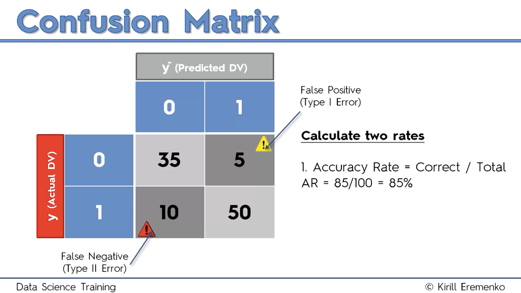

# Visualising the Training set results - Naive Bayes

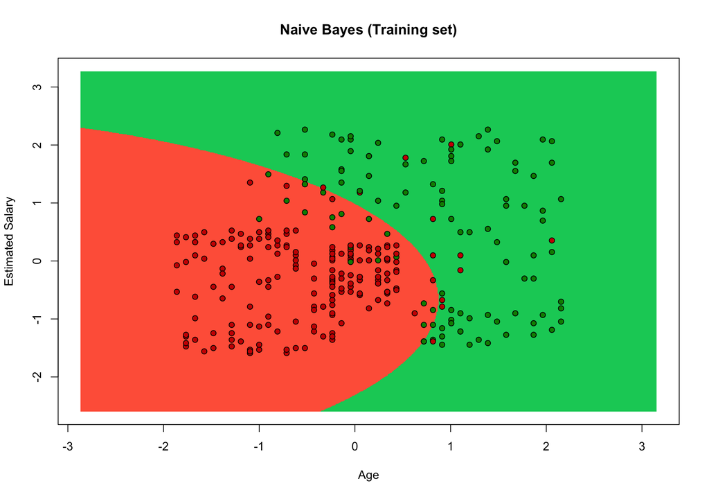

```r
library(ElemStatLearn)
# declare set as the training set
set = training_set
# this section creates the background region red/green. It does that by the 'by' which you can think of as the steps in python, so each 0.01 is interpreted as 0 or 1 and is either green or red. The -1 and +1 give us the space around the edges so the dots are not jammed. Another way to think of the 'by' as is as the resolution of the graphing of the background
X1 = seq(min(set[, 1]) - 1, max(set[, 1]) + 1, by = 0.01)
X2 = seq(min(set[, 2]) - 1, max(set[, 2]) + 1, by = 0.01)
grid_set = expand.grid(X1, X2)
# just giving a name to the X and Y
colnames(grid_set) = c('Age', 'EstimatedSalary')
# this is the MAGIC of the background coloring
# here we use the classifier to predict the result of each of each of the pixel bits noted above
y_grid = predict(classifier, newdata = grid_set)
# that's the end of the background
# now we plat the actual data
plot(set[, -3],
     main = 'Naive Bayes (Training set)',
     xlab = 'Age', ylab = 'Estimated Salary',
     xlim = range(X1), ylim = range(X2)) # this bit creates the limits to the values plotted this is also a part of the MAGIC as it creates the line between green and red
contour(X1, X2, matrix(as.numeric(y_grid), length(X1), length(X2)), add = TRUE)
# here we run through all the y_pred data and use ifelse to color the dots
# note the dots are the real data, the background is the pixel by pixel determination of y/n
# graph the dots on top of the background give you the image
points(grid_set, pch = '.', col = ifelse(y_grid == 1, 'springgreen3', 'tomato'))
points(set, pch = 21, bg = ifelse(set[, 3] == 1, 'green4', 'red3'))
```

# Visualising the Test set results - Naive Bayes

[figure not shown]

```r
library(ElemStatLearn)
set = test_set
X1 = seq(min(set[, 1]) - 1, max(set[, 1]) + 1, by = 0.01)
X2 = seq(min(set[, 2]) - 1, max(set[, 2]) + 1, by = 0.01)
grid_set = expand.grid(X1, X2)
colnames(grid_set) = c('Age', 'EstimatedSalary')
y_grid = predict(classifier, newdata = grid_set)
plot(set[, -3], main = 'SVM Radial Kernel (Test set)',
     xlab = 'Age', ylab = 'Estimated Salary',
     xlim = range(X1), ylim = range(X2))
contour(X1, X2, matrix(as.numeric(y_grid), length(X1), length(X2)), add = TRUE)
points(grid_set, pch = '.', col = ifelse(y_grid == 1, 'springgreen3', 'tomato'))
points(set, pch = 21, bg = ifelse(set[, 3] == 1, 'green4', 'red3'))
```

=========================

Github files; https://github.com/ghettocounselor

Useful PDF for common questions in Lectures;

https://github.com/ghettocounselor/Machine_Learning/blob/master/Machine-Learning-A-Z-Q-A.pdf